# Survival Theory Course

Additive Regression Models

Michael Sachs

# Outline

1. Aalen’s additive model
2. Cox-Aalen, additive multiplicative model
3. Direct binomial regression

# Additive hazard regression

Under the same setup as before, the additive hazard model is
$$\alpha(t | X_i) = \beta_0(t) + \beta_1(t) x_{i1}(t) + \cdots + \beta_p(t) x_{ip}(t),$$
where the $\beta_q(t)$ are regression functions and we define the cumulative regression functions
$$B_q(t) = \int_0^t\beta_q(s) \, ds.$$
Using the fact that $\lambda_i(t) = Y_i(t)\alpha_i(t)$ and the decomposition
$$dN_i(t) = \lambda_i(t)dt + dM_i(t),$$
we now have
$$dN_i(t) = Y_i(t)B_0(t) + \sum_{j=1}^pY_i(t)x_{ij}(t)dB_{j}(t) + dM_i(t).$$
This resembles an ordinary linear regression model.

# Estimation

Letting $\mathbf{N}(t), \mathbf{B}(t)$ and $\mathbf{M}(t)$ denote the column vectors you get by stacking the $n$ observations, and the $n \times (p+1)$ design matrix
$$\mathbf{X}(t) = \left(\begin{array}{c}
Y_1(t) & Y_1(t) x_{11}(t) & \cdots & Y_1(t) x_{1p}(t) \\
\vdots & & & \\
Y_n(t) & Y_n(t) x_{n1}(t) & \cdots & Y_n(t) x_{np}(t)
\end{array}\right).$$
Then the model can be written
$$d\mathbf{N}(t) = \mathbf{X}(t) \, d\mathbf{B}(t) + d\mathbf{M}(t).$$
If $\mathbf{X}(t)$ is invertable, then
$$d\hat{\mathbf{B}}(t) = (\mathbf{X}(t)^\top\mathbf{X}(t))^{-1}\mathbf{X}(t)^\top \, d\mathbf{N}(t) = \mathbf{X}^{-}(t)\, d\mathbf{N}(t)$$
and if we let $J(s)$ be the indicator that $\mathbf{X}(s)$ is invertable, then the cumulative coefficient estimate is
$$\hat{\mathbf{B}}(t) = \int_0^t J(u)\mathbf{X}^-(t)\, d\mathbf{N}(u).$$

# Analysis of $\hat{\mathbf{B}}(t)$

Let $\mathbf{B}^*(t) = \int_0^tJ(u)\,d\mathbf{B}(u)$, then we can study the bias term
$$\hat{\mathbf{B}}(t) - \mathbf{B}^*(t) = \int_0^t J(u)\mathbf{X}^-(u)\, d\mathbf{M}(u),$$
arguing as before, that asymptotically, $\mathbf{B}^*(t)$ is close enough to $\mathbf{B}(t)$.

This is a stochastic integral with respect to a vector valued martingale. All of the properties we studied for univariate martingales have vector valued versions, including a multvariate martingale central limit theorem. One key distinction is the form of the predictable and optional variation processes:

$$\langle \hat{\mathbf{B}} - \mathbf{B}^* \rangle (t) = \int_0^t J(u) \mathbf{X}^-(u) \mbox{diag}(\mathbf{\lambda}(u)\,du)\mathbf{X}^-(u)^\top,$$
and
$$[\hat{\mathbf{B}} - \mathbf{B}^*] (t) = \int_0^t J(u) \mathbf{X}^-(u) \mbox{diag}(d\mathbf{N}(u))\mathbf{X}^-(u)^\top,$$
where $\mathbf{\lambda}(u)$ is the vector of intensity processes, and $\mbox{diag}(v)$ is the diagonal matrix with $v$ as the diagonal.

# Asymptotics

If
$$n \langle \hat{\mathbf{B}} - \mathbf{B}^* \rangle (t) \rightarrow \Sigma(t)$$
then the martingale central limit theorem says that $\sqrt{n}(\hat{\mathbf{B}} - \mathbf{B}^*)$ converges to a multivariate Gaussian martingale with covariance function $\Sigma(t)$. $\Sigma(t)$ can be estimated by

$$\hat{\Sigma}(t) = [\hat{\mathbf{B}} - \mathbf{B}^*] (t) = \sum_{T_j \leq t}J(T_j) \mathbf{X}^-(T_j) \mbox{diag}(\Delta \mathbf{N}(T_j))\mathbf{X}^-(T_j)^\top,$$
or, plugging in the estimates to the expression for the intensity function
$$\tilde{\Sigma}(t) = \widehat{\langle \hat{\mathbf{B}} - \mathbf{B}^*\rangle (t)} = \sum_{T_j \leq t}J(T_j) \mathbf{X}^-(T_j) \mbox{diag}(\mathbf{X}(T_j)\Delta \hat{\mathbf{B}}(T_j))\mathbf{X}^-(T_j)^\top.$$

# Interpretation

The cumulative regression functions are usually plotted for each covariate, along with confidence intervals
$$\hat{B}_q(t) \pm z_{1 - \alpha/2}\sqrt{\Sigma_{(q,q)}(t)}.$$
> One should focus on the slope of the estimated curve and judge how this changes over time.

Alternatively, one can use kernel smoothing to get a smoothed estimate of the derivative of the cumulative functions, i.e., a plot of $\hat{\beta}_q(t)$.

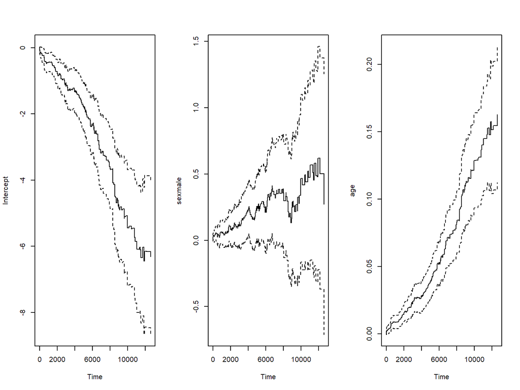

```r
library(survival)
par(mfrow = c(1, 3))
plot(aareg(Surv(futime, death) ~ sex + age, data = mgus))
```

# Interpretation as relative survival

Relative survival is interpreted in the context of an “excess hazard” model:
$$\alpha(t | X) = \alpha^*(t | X) + v(t, Z),$$
where $\alpha^*$ is called the “expected” hazard and $v$ is the excess hazard due to the presence of some disease (usually cancer). $\alpha^*$ is typically estimated using external data (e.g., life tables for a population reported by a national register).

In terms of survival, we have
$$S(t | X) = \exp(-\alpha(t|X)) = S^*(t | X) \exp(-v(t, Z)).$$

In an Aalen model, if the $j$th variable is dichotomous then
$$\exp(-\hat{B}_j(t))$$
can be interpreted as the adjusted relative survival function of covariate $j$ “comparing the survival of individuals that are similar except for differences in one covariate”.

# Testing cumulative coefficients

We may want to test the null hypothesis:
$$H_0: B_q(t) = 0, \mbox{ all } t \in [0, t_0].$$
Under the null, the test statistic
$$Z_q(t_0) = \int_0^{t_0}L_q(t) \, d\hat{B}_q(t) = \sum_{T_j \leq t_0} L_q(T_j)\Delta \hat{B}_q(T_j)$$
is a stochastic integral for a predictable $L_q(t)$ which is a weight process that equals 0 whenever $J(t) = 0$. Hence the predictable variation
$$\langle Z_q \rangle(t_0) = \int_0^{t_0}L^2_q(t) \, d\langle \hat{B}_q \rangle(t).$$
Replacing $\langle \hat{B}_q \rangle(t)$ with the estimated version, we can standardize the test statistic and compare it to a standard normal.

The weight process $L$ can be based on the diagonal of the matrix
$$K(t) = \left\{\mbox{diag}((X(t)^\top X(t))^{-1})\right\}^{-1}.$$

# Additive multiplicative model

We have the Cox model,
$$\lambda_i(t) = Y_i(t)\lambda_0(t) \exp(X_i(t)^\top\beta(t))$$
and the Aalen additive model
$$\lambda_i(t) = Y_i(t)X_i^\top(t)\beta(t).$$
Various attempts have been made to combine the two. Scheike and Zhang (2002) summarize those attempts and propose a new one
$$\lambda_i(t) = Y_i(t) X_i^\top(t)\alpha(t)\exp(Z_i(t)^\top\beta(t)),$$
where the covariates of interest are in $X_i$, while the $Z_i$ are more flexibly modeled.

# Estimation of the additive-multiplicative model

They derive the likelihood:
$$\prod_i \prod_{t \leq \tau} (Y_i(t)(X_i^\top(t)\,dA(t))\exp(Z_i(t)^\top\beta(t))^{dN_it(t)})\times$$
$$\exp\left(-\int_0^\tau Y_i(t)(X_i(t)^\top \alpha(t))\exp(Z_i(t)^\top\beta)\, ds\right)$$
where $A(t) = \int_0^t \alpha(s) ds$.

It is of interest to estimate both $dA(t)$ (nonparametrically) and $\beta$.

1. They derive the scores for $dA$ first, and then argue that a similar weighted least squares estimator as in the Aalen model solves the scores.
2. They show that the scores for $\beta$ have mean zero at the true value of $\beta$ no matter what the weight matrix is in step 1.
3. They then derive the efficient weight matrix and information.
4. Asymptotic properties follow under the usual assumptions.

# Example

Using the `timereg` package

```r
library(timereg)
data(sTRACE)

# Fits stratified Cox model
out<-cox.aalen(Surv(time,status==9)~-1+factor(vf)+ prop(age)+prop(sex)+
           prop(chf)+prop(diabetes),data=sTRACE,max.time=7,n.sim=100)
summary(out)
```

```
## Cox-Aalen Model
##
## Test for Aalen terms
## Test not computed, sim=0
##
## Proportional Cox terms :
##                 Coef.     SE Robust SE D2log(L)^-1    z    P-val lower2.5%
## prop(age)      0.0667 0.0075   0.00702     0.00724 9.50 0.00e+00    0.0520
## prop(sex)      0.3760 0.1400   0.13800     0.13700 2.74 6.22e-03    0.1020
## prop(chf)      0.7310 0.1420   0.13900     0.14200 5.25 1.53e-07    0.4530
## prop(diabetes) 0.4000 0.1960   0.18500     0.19400 2.17 3.01e-02    0.0158
##                upper97.5%
## prop(age)          0.0814
## prop(sex)          0.6500
## prop(chf)          1.0100
## prop(diabetes)     0.7840
## Test of Proportionality
##                sup|  hat U(t) | p-value H_0
## prop(age)                147.00         0.26
## prop(sex)                  4.42         0.80
## prop(chf)                  7.21         0.20
## prop(diabetes)             3.76         0.56
```

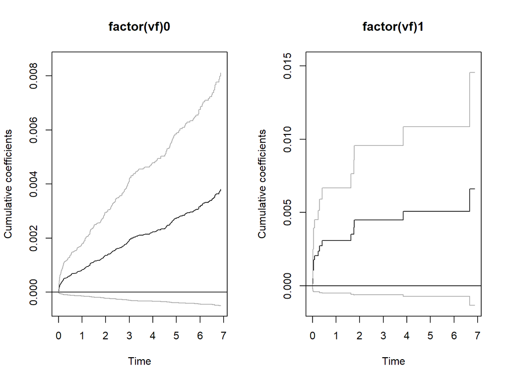

```r
par(mfrow=c(1,2))
plot(out, col = c("black", "grey65"))
```

```r
## Cox-Aalen model
out<-cox.aalen(Surv(time,status==9)~prop(age)+prop(sex)+
               vf+chf+prop(diabetes),data=sTRACE,max.time=7,n.sim=100)
summary(out)
```

```
## Cox-Aalen Model
##
## Test for Aalen terms
## Test not computed, sim=0
##
## Proportional Cox terms :
##                 Coef.      SE Robust SE D2log(L)^-1    z   P-val lower2.5%
## prop(age)      0.0653 0.00742   0.00693     0.00722 9.42 0.00000    0.0508
## prop(sex)      0.3620 0.13900   0.13600     0.13700 2.66 0.00774    0.0896
## prop(diabetes) 0.3950 0.19600   0.18500     0.19400 2.14 0.03240    0.0108
##                upper97.5%
## prop(age)          0.0798
## prop(sex)          0.6340
## prop(diabetes)     0.7790
## Test of Proportionality
##                sup|  hat U(t) | p-value H_0
## prop(age)                123.00         0.41
## prop(sex)                  4.16         0.82
## prop(diabetes)             3.80         0.55
```

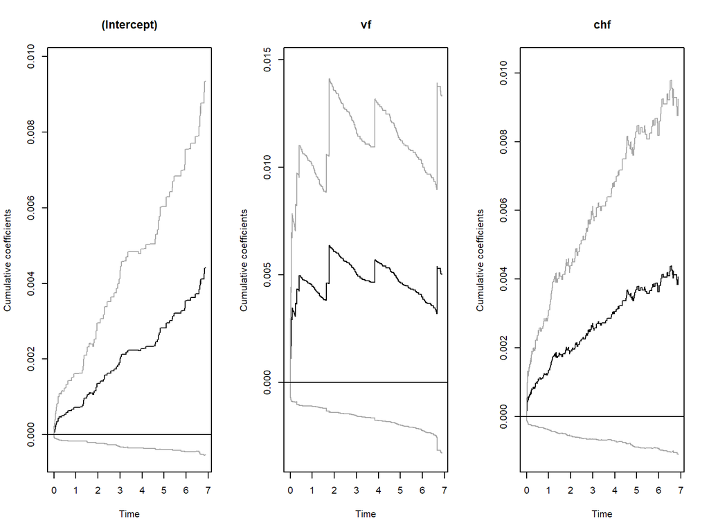

```r
par(mfrow=c(1,3))
plot(out,col = c("black", "grey65"))
```

# Direct binomial regression

Scheike, Zhang, and Gerds (2008) propose a model
$$P(T_i \leq t | X_i) = h\{X_i^\top\eta(t)\}$$
where $h$ is an inverse link function, and the coefficients may be time varying.

Under the assumption
$$E(\delta_i | X_i = x, T_i = t) = P(C_i > t | X_i = x) := G(t | x),$$
they propose

1. To estimate $G(t | x)$ using Kaplan-Meier or Aalen’s additive model (or Cox)
2. Solve the score equations
   $$\sum_{i = 1}^n \frac{\partial h\{X_i^\top\eta(t)\}}{\partial \eta} w(t, X_i) \left(\frac{\delta_i N_i(t)}{\hat{G}(t)(T_i | X_i)} - h\{X_i^\top\eta(t)\}\right),$$
   with some weight function $w$.

This is very similar to inverse probability weighting for missing data.

The model is consistent no matter what the weight function is, but they are now working on deriving the efficient score for this model.

Also related is the pseudo-observation approach, which we will discuss in the special topics week, but that approach involves using all observations in the estimating equations, not just the uncensored ones.

# Example

From the R package `mets`

```r
library(mets)
data(bmt)
# logistic regresion with IPCW binomial regression
out <- binreg(Event(time,cause)~tcell+platelet,bmt,time=50)
summary(out)
```

```
##
##    n events
##  408    160
##
##  408 clusters
## coeffients:
##              Estimate   Std.Err      2.5%     97.5% P-value
## (Intercept) -0.178043  0.127210 -0.427370  0.071285  0.1616
## tcell       -0.426984  0.348033 -1.109116  0.255147  0.2199
## platelet    -0.441698  0.242422 -0.916837  0.033440  0.0685
##
## exp(coeffients):
##             Estimate    2.5%  97.5%
## (Intercept)  0.83691 0.65222 1.0739
## tcell        0.65247 0.32985 1.2907
## platelet     0.64294 0.39978 1.0340
```

```r
predict(out,data.frame(tcell=c(0,1),platelet=c(1,1)),se=TRUE)
```

```
##        pred         se     lower     upper
## 1 0.3498404 0.04859196 0.2546001 0.4450806
## 2 0.2598545 0.07039433 0.1218816 0.3978273
```

# Summary

1. Additive models are appealing to some statisticians because they don’t require smoothing or choice of time intervals to split.
2. The interpretation is actually not too tricky, but it has not been widely used in clinical/epi literature.
3. Appeal to the relative survival interpretation, which is very common in cancer epidemiology.
4. If the effect up to a single time point is of primary interest, use binomial regression. Easy interpretation, and familiar models that use slight variations on standard estimation procedures.
5. Additive and cumulative models are particularly appealing for causal inference.

For more of this sort of research, consider the book

*Dynamic Regression Models for Survival Data* (2006) by Torben Martinussen and Thomas H. Scheike.